# Whisk(e)y

August Warren

Thursday, September 14, 2017

```r
library("ggplot2")
library("directlabels")
library("plyr")
library("ggthemes")
```

[figure not shown]

Earlier this month, I went to a bar in Minneapolis called “Merlin’s Rest” with one of the most impressive scotch collections I’ve ever seen compiled in a whisky bible (see: http://merlinsrest.com/whiskywhiskey/the-whisky-bible/). Certain whiskies aged about 30 years ran over $200 for a single pour. This got me thinking a lot about the relationship of the age and price of whisky.

So I did what any reasonable person did and found an API (https://github.com/WhiskeyProject/whiskey-api) to scrape the data and look at the relationship.

Once I gathered the data (for those interested: https://github.com/GWarrenn/whisky/blob/master/whisky.py), the first thing I wanted to do was to run a simple linear regression on price and age to show the relationship between the two.

```r
whisky_data_w_years <- read.csv("whisky.csv")

y <- whisky_data_w_years$price
x <- whisky_data_w_years$year
```

```r
initial_model <- lm(y ~ x)

initial_model
```

```
##
## Call:
## lm(formula = y ~ x)
##
## Coefficients:
## (Intercept)            x
##       4.972        4.374
```

We can then use this model as way to roughly predict what the average 15-year bottle of whisky would cost.

```r
predict(initial_model,data.frame(x=15),interval="confidence")
```

```
##        fit      lwr      upr
## 1 70.58495 65.18556 75.98434
```

And here is the relationship plotted out. The data also contains an average user rating, more on that later.

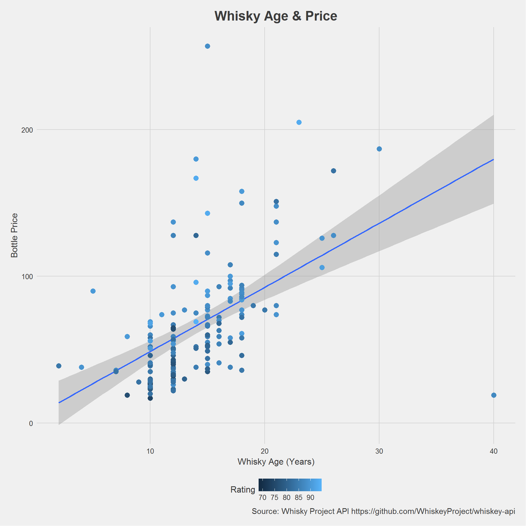

However, the r-squared for this model isn’t incredibly high, indicating that something other than age is determining the price of the bottle.

```r
summary(initial_model)$r.squared
```

```
## [1] 0.250382
```

However, once we control for the whisky’s origin, we see a modest increase in the overall fit of the model. In some regions we actually see a negative coefficients, while regions like Japan have a crazy high coefficient.

```r
y <- whisky_data_w_years$price
x <- whisky_data_w_years$year
r <- whisky_data_w_years$region

model_w_region <- lm(y ~ x + r)

model_w_region
```

```
##
## Call:
## lm(formula = y ~ x + r)
##
## Coefficients:
##  (Intercept)             x  rCampbeltown     rHighland        rIrish
##      -2.4566        4.6775       33.3681       -6.3186        0.7621
##      rIsland        rIslay        rJapan        rOther          rRye
##      12.8047       -0.4906       30.6721      -47.3349       13.1925
##    rSpeyside
##       2.8071
```

```r
summary(model_w_region)$r.squared
```

```
## [1] 0.3650731
```

We can also use the region to predict the value of an average bottle of 15 year whisky from various parts of the world.

```r
predict(model_w_region,data.frame(x=15,r="Speyside"),interval="confidence")
```

```
##        fit      lwr      upr
## 1 70.51283 62.58164 78.44401
```

```r
predict(model_w_region,data.frame(x=15,r="Japan"),interval="confidence")
```

```
##        fit     lwr      upr
## 1 98.37786 73.6761 123.0796
```

```r
predict(model_w_region,data.frame(x=15,r="Highland"),interval="confidence")
```

```
##        fit      lwr      upr
## 1 61.38712 46.76915 76.00509
```

The next step was to use the rating data that users have contributed along with the prices to segment the whiskies by average price and rating.

Tip: Beware of the top-left and seek out the bottom right.

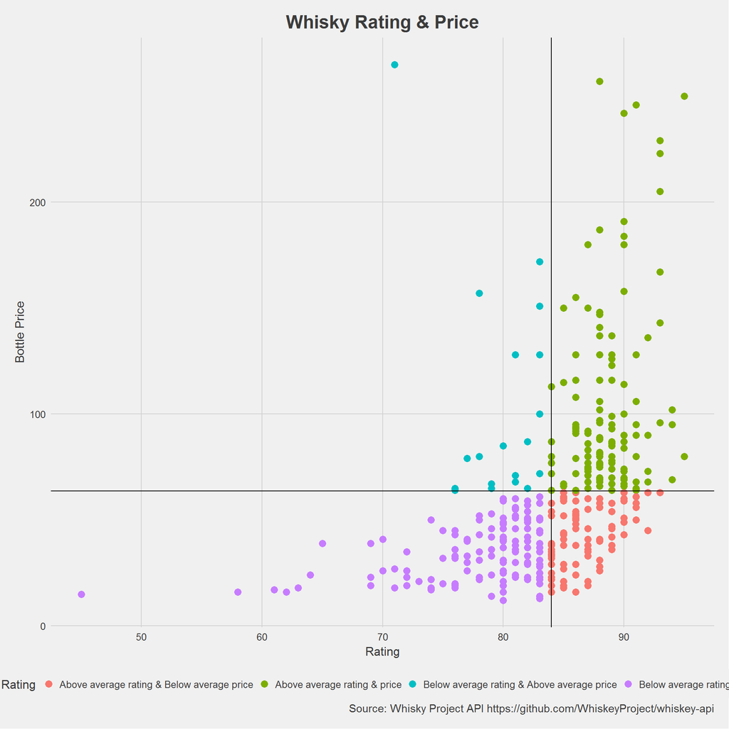

Last but not least, I wanted to find good “value” whiskies, whisky’s that are on the lower end of the price spectrum but have generally higher ratings. I measured this by dividing the rating by price to create a rough “best value” measure.

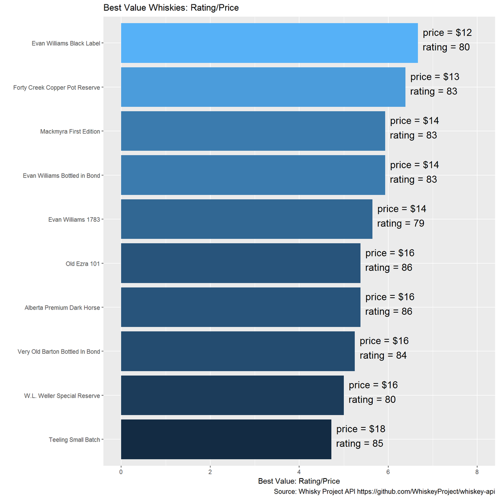